# Exploring the BRFSS data

## Setup

### Load packages

```r
library(ggplot2)
library(dplyr)
library(zoo)
library(vcd)
library(GGally)
library(stargazer)
```

### Load data

Read in the concerned data, `brfss2013.RData`, also with a `load()` command.

```r
load("brfss2013.RData")
```

## Part 1: Data

### Data Collection and Scope of Inferrence

The Behavioral Risk Factor Surveillance System (BRFSS) is a collaborative project between all of the states in the United States (US) and participating US territories and the Centers for Disease Control and Prevention (CDC). BRFSS is an ongoing surveillance system designed to measure behavioral risk factors for the non-institutionalized adult population (18 years of age and older) residing in the US.The BRFSS objective is to collect uniform, state-specific data on preventive health practices and risk behaviors that are linked to chronic diseases, injuries, and preventable infectious diseases that affect the adult population.

To collect relevant data, BRFSS conducts both landline telephone- and cellular telephone-based surveys. In conducting the BRFSS landline telephone survey, interviewers collect data from a randomly selected adult in a household. In conducting the cellular telephone version of the BRFSS questionnaire, interviewers collect data from an adult who participates by using a cellular telephone and resides in a private residence or college housing. `[1]`

In terms of data collection for landline telephones, BRFSS randomly select adults from households. **Conclusions based on these data, with random sampling, can be generalized to the whole adult population residing in the US households within landline telephone coverage in the year 2013**.

As to cellular telephone version, **the generalizability of conclusions are limited to a population receiving at least 90 percent or more of their calls on cellular telephones residing in private residence or college housing in the US within telephone coverage in the year 2013**.

As to causality, since the surveys are observational, **we are merely capable to draw conclusions on associations among variables**.

*([1]source: Overview-BRFSS 2013, https://www.cdc.gov/brfss/annual_data/2013/pdf/Overview_2013.pdf, accessed at 08/13/2017)*

### Vairables and Observations

By `str()` command, we can get a general impression of the data set that there are **491775** observations of **330** variables.

```r
str(brfss2013)
```

```
## 'data.frame':    491775 obs. of  330 variables:
##  $ X_state  : Factor w/ 55 levels "0","Alabama",..: 2 2 2 2 2 2 2 2 2 2 ...
##  $ fmonth   : Factor w/ 12 levels "January","February",..: 1 1 1 1 2 3 3 3 4 4 ...
##  $ idate    : int  1092013 1192013 1192013 1112013 2062013 3272013 3222013 3042013 4242013 4242013 ...
##  $ imonth   : Factor w/ 12 levels "January","February",..: 1 1 1 1 2 3 3 3 4 4 ...
##  $ iday     : Factor w/ 31 levels "1","2","3","4",..: 9 19 19 11 6 27 22 4 24 24 ...
##  $ iyear    : Factor w/ 2 levels "2013","2014": 1 1 1 1 1 1 1 1 1 1 ...
##  $ dispcode : Factor w/ 2 levels "Completed interview",..: 1 1 1 1 1 1 1 1 1 1 ...
##  $ seqno    : int  2013000580 2013000593 2013000600 2013000606 2013000608 2013000630 2013000634 2013000644 2013001305 2013001338 ...
##  $ X_psu    : int  2013000580 2013000593 2013000600 2013000606 2013000608 2013000630 2013000634 2013000644 2013001305 2013001338 ...
##  $ ctelenum : Factor w/ 1 level "Yes": 1 1 1 1 1 1 1 1 1 1 ...
##  $ pvtresd1 : Factor w/ 2 levels "Yes","No": 1 1 1 1 1 1 1 1 1 1 ...
##  $ colghous : Factor w/ 1 level "Yes": NA NA NA NA NA NA NA NA NA NA ...
##  $ stateres : Factor w/ 1 level "Yes": 1 1 1 1 1 1 1 1 1 1 ...
##  $ cellfon3 : Factor w/ 1 level "Not a cellular phone": 1 1 1 1 1 1 1 1 1 1 ...
```

[output cut: 86 more lines]

### Scrutiniztion, Elimination, and Classification of Observations

According to the code book, the variable dispcode denotes the final disposition of the interview, including `"Completed interview"`, `"Partially completed interview"` and `"NA"`.

```r
brfss2013 %>%
  group_by(dispcode) %>%
  summarise(count = n())
```

```
## # A tibble: 3 x 2
##                        dispcode  count
##                          <fctr>  <int>
## 1           Completed interview 433222
## 2 Partially completed interview  58548
## 3                            NA      5
```

According to the frequecy check above, the partially completed ones take a large propotion in the whole sample (approximately 12%), so we cannot eliminate these observations. Rather, as these observations may include the information needed for forthcoming research questions, we should take them as an effective part of the sample at the present stage. However, we should now exclude the ones with `"NA"` value.

```r
brfss2013_comp <- brfss2013 %>% filter(dispcode != "NA")
rm(brfss2013)
```

The variables `ctelenum` and `ctelnum1` imply whether a specific observation accords with the desired sampled individual. Hence, those fail to keep identical should be eliminated in consideration of the accuracy of random sampling.

```r
brfss2013_comp %>%
  group_by(ctelenum, ctelnum1) %>%
  summarise(count = n())
```

```
## # A tibble: 4 x 3
## # Groups:   ctelenum [?]
##   ctelenum ctelnum1  count
##     <fctr>   <fctr>  <int>
## 1      Yes      Yes 131574
## 2      Yes        7     28
## 3      Yes       NA 360132
## 4       NA       NA     36
```

```r
brfss2013_adj <- brfss2013_comp %>%
  filter(ctelenum != "NA")
rm(brfss2013_comp)
```

Still, note that values of the variable `ctelnum1` equal to `"7"` for 28 observations. With no relevant explainations found in the code book, we should regard these values as `"NA"`. In order to select the observations with `"NA"` value under the variable `ctelnum1`, we could assign `"7"` to them for convenience.

```r
brfss2013_adj$ctelnum1[is.na(brfss2013_adj$ctelnum1)] <- 7
```

We should then classify the whole sample into a **landline based collection** and a **cellular based collection**, for the different population involved.

```r
brfss2013_cell <- brfss2013_adj %>%
  filter(ctelenum == "Yes", ctelnum1 == "Yes")
brfss2013_land <- brfss2013_adj %>%
  filter(ctelenum == "Yes", ctelnum1 == 7)
rm(brfss2013_adj)
```

In each collection, we should also scrutinize if the observations truly accords to the distinguished characteristics of their population. If not, we should eliminate those fail to accord.

Firstly, we need to adjust the cellular collection, and make sure the adjusted collection only contains observations that meet the following criteria besides correct cellular telephone number: this is a cellular telephone; the percentage of calls received through this specific cellular telephone is 90 percent or more; the individual lives either in a private residence or a college housing; the individual is an adult.

```r
brfss2013_cell <- brfss2013_cell %>%
  mutate(frequent_cell = ifelse(pctcell >= 90, "TRUE", "FALSE"))
brfss2013_cell %>%
  group_by(cadult, frequent_cell) %>%
  summarise(count = n())
```

```
## # A tibble: 6 x 3
## # Groups:   cadult [?]
##                   cadult frequent_cell count
##                   <fctr>         <chr> <int>
## 1   Yes, male respondent         FALSE    13
## 2   Yes, male respondent          TRUE 12923
## 3   Yes, male respondent          <NA> 54479
## 4 Yes, female respondent         FALSE    15
## 5 Yes, female respondent          TRUE 11878
## 6 Yes, female respondent          <NA> 52266
```

```r
brfss2013_cell_adj <- brfss2013_cell %>%
  filter(cellfon2 == "Yes", pctcell >= 90)
brfss2013_cell_college_housing <- brfss2013_cell_adj %>%
  filter(pvtresd2 == "No", cclghous == "Yes")
brfss2013_cell_adj$cclghous[is.na(brfss2013_cell_adj$cclghous)] <- "No"
brfss2013_cell_private_residence <- brfss2013_cell_adj %>%
  filter(pvtresd2 == "Yes", cclghous == "No")
rm(brfss2013_cell, brfss2013_cell_adj)
```

Notice that although massive observations are eliminated due to their missing values under `frequent_cell`, we have to sacrifice them to obtain an adjusted effective sample. As a result, we’ve attained the data set `brfss_cell_private_residence` as an **adult private residence resident collection for cellular telephones** from the adjusted cellular telephone sample, and another `brfss_cell_college_housing` as an **adult college housing resident collection for cellular telephones**.

Secondly, we should adjust the landline collection, and make sure the adjusted collection only contains observations that meet the following criteria besides correct landline telephone number: the individual lives either in a private residence or a college housing; the individual is an adult. Notice that as a students with families can also register for college housing, we simply also regard them as residents in households.

```r
brfss2013_land %>%
  group_by(ladult, X_age65yr) %>%
  summarise(count = n())
```

```
## # A tibble: 8 x 3
## # Groups:   ladult [?]
##                   ladult       X_age65yr  count
##                   <fctr>          <fctr>  <int>
## 1   Yes, male respondent    Age 18 to 64     13
## 2   Yes, male respondent Age 65 or older      6
## 3 Yes, female respondent    Age 18 to 64     12
## 4 Yes, female respondent Age 65 or older      6
## 5 Yes, female respondent              NA      1
## 6                     NA    Age 18 to 64 207664
## 7                     NA Age 65 or older 148647
## 8                     NA              NA   3811
```

```r
brfss2013_land %>%
  group_by(pvtresd1, colghous) %>%
  summarise(count = n())
```

```
## # A tibble: 3 x 3
## # Groups:   pvtresd1 [?]
##   pvtresd1 colghous  count
##     <fctr>   <fctr>  <int>
## 1      Yes       NA 360087
## 2       No      Yes     44
## 3       NA       NA     29
```

```r
brfss2013_land_adj <- brfss2013_land %>%
  filter(X_age65yr == "Age 18 to 64" | X_age65yr == "Age 65 or older")
brfss2013_land_households <- brfss2013_land_adj %>%
  filter(pvtresd1 == "Yes" | colghous == "Yes")
rm(brfss2013_land, brfss2013_land_adj)
```

We could draw the collection `brfss2013_land_households` from the original collection, for the **adult household resident collection for landline telephones**

Up to now, we’ve obtained all the data sets to work with.

## Part 2: Research questions

### Research quesion 1:

Information economists pay much attention at the **Moral Hazard**`[2]`. Moral hazard occurs when one person takes more risks because someone else bears the cost of those risks. It could be the case that those with health insurance coverage, especially for those aged from 18 to 64, are more likely to take risky behaviours detrimental to health, as elder ones over 64 are less significantly likely to do so risking their lives. These detrimental risky behaviours include over-consumption of tobacco or alcohol.

*([2]source: Wikipedia, https://en.wikipedia.org/wiki/Moral_hazard, accessed at 08/27/2017)*

For research question 1, we would like to find out whether moral hazard exsists. In other words, **whether health insurance coverage and likelihood of detrimental risky behaviours are positively dependent, among the whole adult population aged from 18 to 64 residing in the US households within telephone coverage in the year 2013**.

### Research quesion 2:

The discussion for research question 1 ends up with a controversial conclusion against our initial reseach hypothesis. However, the dependence between health insurance coverage and risky behaviours detrimental to health could be confusing. According to the graphs and plots, we notice a potential negative association: the level of one’s risk behaviours seems to be higher when the individual do not have health insurance coverage, and lower when the person has. The dependence is confusing as the effect of moral hazard predicts a controversial association theoretically instead.

A potential explaination for the controversion lies in omitted variables. In other words, there might be variables, as characters of those with health insurance coverage, that negatively associate with the level of risky behaviours. For instance, income and education. We might expect those with higher income and education to purchase for regular health insurance, while conducting risky behaviours detrimental to their health less frequently.

For research question 2, **we would like to scrutinize the potential omitted variables in the model of the previous research question: income and education. The population keeps identical: the whole adult population aged from 18 to 64 residing in the US households within telephone coverage in the year 2013**.

### Research quesion 3:

We’ve made an in-depth investigation into some determiants of risky behaviours detrimental to health already, and as for research question 3, the topic of interest turns to body mass. In particular, as obesity in the US has consistently been a sexy issue, we would like to learn a bit about habits possibly affect weight.

In other words, **research in the last section concentrates on the determinants of body mass. Potential habits that affect weight include sleep, excercise, and eating habits. The population of interest is the whole adult population aged from 18 to 64 who receive at least 90% or more of their calls on cellular telephones and reside in private residence in the US within telephone coverage in the year 2013.**

## Part 3: Exploratory data analysis

### Research quesion 1:

Limited by the data accessible, we could define the detrimental risky behaviours as binge drinking, heavy alcohol consumption, and somoking everyday. Relevant variables are: `X_smoker3`, `X_rfbing5`, `X_rfdrhv4`.

Taking age group division and health coverage into consideration, we may also include the variables of `X_age65yr` and `X_hcvu651`.

In order to avoid having to eliminate observations from scratch for research question 1, we might also include the variables `X_incomg` and `X_educag`.

```r
brfss2013_moral_hazard1 <- brfss2013_land_households %>%
  select(X_age65yr, X_hcvu651, X_smoker3, X_rfbing5, X_rfdrhv4,  X_incomg, X_educag)
str(brfss2013_moral_hazard1)
```

```
## 'data.frame':    356320 obs. of  7 variables:
##  $ X_age65yr: Factor w/ 2 levels "Age 18 to 64",..: 1 1 1 1 2 1 1 1 1 2 ...
##  $ X_hcvu651: Factor w/ 2 levels "Have health care coverage",..: 1 1 1 1 NA 1 1 1 1 NA ...
##  $ X_smoker3: Factor w/ 4 levels "Current smoker - now smokes every day",..: 3 4 2 4 3 4 3 1 4 4 ...
##  $ X_rfbing5: Factor w/ 2 levels "No","Yes": 1 1 2 1 1 1 1 1 1 1 ...
##  $ X_rfdrhv4: Factor w/ 2 levels "No","Yes": 1 1 2 1 1 1 1 1 1 1 ...
##  $ X_incomg : Factor w/ 5 levels "Less than $15,000",..: 5 5 5 5 4 5 NA 4 5 2 ...
##  $ X_educag : Factor w/ 4 levels "Did not graduate high school",..: 4 3 4 2 4 4 2 3 4 2 ...
```

**Elimination of Observations** As we are merely interested in the adult population aged between 18 to 64, we should eliminate those aged 65 or older. Besides, we should further eliminate observations with `"NA"` for the variable `X_hcvu651`.

In order to measure the level of detrimental risky behaviours and compare among observations fairly, we also need to eliminate the observations value merely with `"NA"` for each behaviour.

```r
brfss2013_moral_hazard_adj <- brfss2013_moral_hazard1 %>%
  filter(X_age65yr == "Age 18 to 64" &
         X_hcvu651 != "NA" &
         X_smoker3 != "NA" &
         X_rfbing5 != "NA" &
         X_rfdrhv4 != "NA")
rm(brfss2013_moral_hazard1)
```

**Calculation of New Variables**

A calculated variable based on the preceding variables is necessary for further analyses, serving as a measure of the level of detrimental risky behaviours, named `risk_level`. Calculate `risk_level` under the following rules in the tables for over-consumption of tobacco:

```r
risk_level_smoke <- matrix(c("               3", "               2", "               1", "               0"), ncol=1, nrow=4)
colnames(risk_level_smoke) <- c("Level of over-consumption of tobacco")
rownames(risk_level_smoke) <- c("Current smoker - now smokes every day", "Current smoker - now smokes some days", "Former smoker", "Never smoked")
risk_level_smoke <- as.table(risk_level_smoke)
risk_level_smoke
```

```
##                                       Level of over-consumption of tobacco
## Current smoker - now smokes every day                3
## Current smoker - now smokes some days                2
## Former smoker                                        1
## Never smoked                                         0
```

```r
rm(risk_level_smoke)
```

As for the rules of calculating risk level for over-consumption of alcohol:

```r
risk_level_drunk <- matrix(c("               3", "               2", "               1", "               0"), ncol=1, nrow=4)
colnames(risk_level_drunk) <- c("Level of over-consumption of alcohol")
rownames(risk_level_drunk) <- c("Binge drinking & heavy alcohol", "Binge drinking but not heavy alcohol", "Heavy alcohol but not binge drinking", "Neither")
risk_level_drunk <- as.table(risk_level_drunk)
risk_level_drunk
```

```
##                                      Level of over-consumption of alcohol
## Binge drinking & heavy alcohol                      3
## Binge drinking but not heavy alcohol                2
## Heavy alcohol but not binge drinking                1
## Neither                                             0
```

```r
rm(risk_level_drunk)
```

With the rules above, we are capable of calculating the variable `risk_level` for tobacco and alcohol over-consumption. To get the total `risky_behaviours_level`, we simply add the values for `risk_level` up.

```r
brfss2013_moral_hazard_adj <- brfss2013_moral_hazard_adj%>%
  mutate(tobacco_risk_level=ifelse(X_smoker3 == "Current smoker - now smokes every day", 3,
                            ifelse(X_smoker3 =="Current smoker - now smokes some days", 2,
                            ifelse(X_smoker3 =="Former smoker", 1, 0))))
brfss2013_moral_hazard_adj <- brfss2013_moral_hazard_adj%>%
  mutate(alcohol_risk_level=ifelse(X_rfbing5 == "Yes" & X_rfdrhv4 == "Yes", 3,
                            ifelse(X_rfbing5 == "Yes" & X_rfdrhv4 == "No", 2,
                            ifelse(X_rfbing5 == "No" & X_rfdrhv4 == "Yes", 1, 0))))
brfss2013_moral_hazard_adj <- brfss2013_moral_hazard_adj%>%
  mutate(risky_behaviours_level=tobacco_risk_level+alcohol_risk_level)
brfss2013_moral_hazard_adj$risky_behaviours_level <- factor(brfss2013_moral_hazard_adj$risky_behaviours_level)
brfss2013_moral_hazard <- brfss2013_moral_hazard_adj%>%
  select(X_hcvu651, risky_behaviours_level)
```

Now we’re ready to visualize the assciation between health insurance coverage and likelihood of detrimental risky behaviours, using contingency table and mosaic plot.

```r
count <- table(brfss2013_moral_hazard$X_hcvu651,
               brfss2013_moral_hazard$risky_behaviours_level)
count
```

```
##
##                                        0     1     2     3     4     5
##   Have health care coverage        90047 36295 14112 22196  3785  3069
##   Do not have health care coverage 10979  4636  2231  5074   691   954
##
##                                        6
##   Have health care coverage         1820
##   Do not have health care coverage   613
```

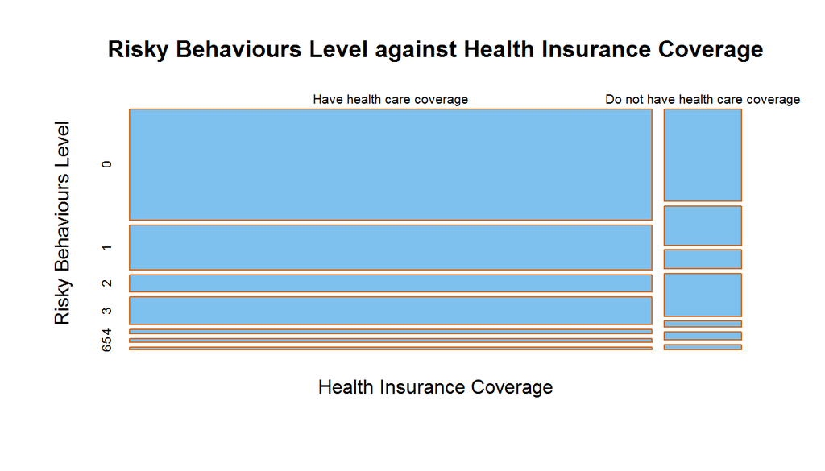

```r
mosaicplot(count, main = "Risky Behaviours Level against Health Insurance Coverage", xlab = "Health Insurance Coverage", ylab = "Risky Behaviours Level", dir = c("v", "h"),color = "skyblue2", border = "chocolate")
```

From the mosiac plot above, we may assume that the risky behaviours level and health insurance coverage are dependent. Unfortunately, it’s not likely that a moral hazard exists. Contrarily, the level of one’s risk behaviours seems to be higher when the individual do not have health insurance coverage, and lower when the person has. In order to scrutinize the possible dependence, we need a chi-sqare indenpendence test, as both variables are categorical and `risk_behaviours_level` has more than two levels.

Check the conditions of such test: we have a random sample, whose size is less than 10% of its population; both variables have exculudable division of level; and each cell has more than five observations. As all conditions are met, the null hypothesis as that the two variables are independent; while the alternative is that they are dependent.

```r
chisq.test(count)
```

```
##
##  Pearson's Chi-squared test
##
## data:  count
## X-squared = 2042.3, df = 6, p-value < 2.2e-16
```

```r
rm(brfss2013_moral_hazard)
rm(count)
```

According to the test result report above, we have a fairly high chi-square value and a p-value approximately 0. Therefore, we should reject the null, concluding that we are 99% confident that the level of one’s risky behaviours is dependent with whether the individual has health insurance coverage or not. Combined with the preceding graphs, **we are 99% confident that health insurance coverage and likelihood of detrimental risky behaviours are dependent, potentially negatively; and the moral hazard doesn’t exist among the whole adult population aged from 18 to 64 residing in the US households within landline telephone coverage in the year 2013.**

### Research quesion 2:

Keep the definition and measure of the level of risky behaviours identical. To measure income level and education, we need to further include the variables `X_incomg` and `X_educag`.

```r
brfss2013_potential_omitted1 <- brfss2013_moral_hazard_adj
rm(brfss2013_moral_hazard_adj)
```

As we’ve included `X_incomg`, `X_educag`, and `risky_behaviours_level` in the data set `brfss2013_moral_hazard_adj`, we only need to further eliminate observations with `"NA"` for `X_incomg` or `X_educag`, and select variables directly relevant to research question 2.

```r
brfss2013_potential_omitted_adj <- brfss2013_potential_omitted1 %>%
  filter(X_incomg != "NA" &
         X_educag != "NA")
rm(brfss2013_potential_omitted1)
brfss2013_potential_omitted <- brfss2013_potential_omitted_adj %>%
  select(X_hcvu651, risky_behaviours_level, X_incomg, X_educag)
str(brfss2013_potential_omitted)
```

```
## 'data.frame':    175692 obs. of  4 variables:
##  $ X_hcvu651             : Factor w/ 2 levels "Have health care coverage",..: 1 1 1 1 1 1 1 1 2 2 ...
##  $ risky_behaviours_level: Factor w/ 7 levels "0","1","2","3",..: 2 1 6 1 1 4 1 1 4 2 ...
##  $ X_incomg              : Factor w/ 5 levels "Less than $15,000",..: 5 5 5 5 5 4 5 5 1 2 ...
##  $ X_educag              : Factor w/ 4 levels "Did not graduate high school",..: 4 3 4 2 4 3 4 4 4 2 ...
```

```r
rm(brfss2013_potential_omitted_adj)
```

In order to scrutinize the potential omitted variables in research question 1, we can first review health insurance coverage against income and education consecutively. These variables are categorical variables and the dependent variable `X_hcvu651` is binomial. Therefore, it’s better to use single categorical predictor logit regression model. In order to report in short, we need to abbreviate the name of each category first.

```r
levels(brfss2013_potential_omitted$X_hcvu651)<-c('Health Insurance', 'Without Health Insurance')
levels(brfss2013_potential_omitted$X_incomg)<-c('<$15,000', '$15,000-$25,000','$25,000-$35,000','$35,000-$50,000', '>$50,000')
levels(brfss2013_potential_omitted$X_educag)<-c('< High School', 'High School (G)', 'College (A)', 'College (G)')
brfss2013_potential_omitted$X_hcvu651 = relevel(brfss2013_potential_omitted$X_hcvu651, ref="Without Health Insurance")
```

Following is the model for health insurance coverage against education and its odds-ratio interpretation.

```r
m_cover_education <- glm(X_hcvu651 ~ X_educag, data=brfss2013_potential_omitted, family="binomial")
summary(m_cover_education)
```

```
##
## Call:
## glm(formula = X_hcvu651 ~ X_educag, family = "binomial", data = brfss2013_potential_omitted)
##
## Deviance Residuals:
##     Min       1Q   Median       3Q      Max
## -2.4001   0.3399   0.3399   0.6295   0.8845
##
## Coefficients:
##                         Estimate Std. Error z value Pr(>|z|)
## (Intercept)              0.73659    0.02096   35.15   <2e-16 ***
## X_educagHigh School (G)  0.78161    0.02425   32.24   <2e-16 ***
## X_educagCollege (A)      1.16806    0.02491   46.88   <2e-16 ***
## X_educagCollege (G)      2.08583    0.02657   78.51   <2e-16 ***
## ---
## Signif. codes:  0 '***' 0.001 '**' 0.01 '*' 0.05 '.' 0.1 ' ' 1
##
## (Dispersion parameter for binomial family taken to be 1)
##
##     Null deviance: 132046  on 175691  degrees of freedom
## Residual deviance: 124368  on 175688  degrees of freedom
## AIC: 124376
##
## Number of Fisher Scoring iterations: 5
```

```r
odds_cover_education = exp(coef(m_cover_education))-1
stargazer(m_cover_education, type="text", coef=list(odds_cover_education))
```

```
##
## ===================================================
##                             Dependent variable:
##                         ---------------------------
##                                  X_hcvu651
## ---------------------------------------------------
## X_educagHigh School (G)          1.185***
##                                   (0.024)
##
## X_educagCollege (A)              2.216***
##                                   (0.025)
##
## X_educagCollege (G)              7.051***
##                                   (0.027)
##
## Constant                         1.089***
##                                   (0.021)
##
## ---------------------------------------------------
## Observations                      175,692
## Log Likelihood                  -62,184.110
## Akaike Inf. Crit.               124,376.200
## ===================================================
## Note:                   *p<0.1; **p<0.05; ***p<0.01
```

```r
rm(m_cover_education)
rm(odds_cover_education)
```

As observed in the reports above, under a significance level of 1%, relative to those who did not graduate high school, the odds of having health insurance coverage for sampled individuals who graduated high school is 119% higher; for those who attended college or technical school, it is 222% higher; and for those who graduated college or technical school, it’s 706% higher. **In short, those with higher education level are more likely to have health insurance coverage.**

Following is the model for health insurance coverage against income and its odds-ratio interpretation.

```r
m_cover_income <- glm(X_hcvu651 ~ X_incomg, data=brfss2013_potential_omitted, family="binomial")
summary(m_cover_income)
```

```
##
## Call:
## glm(formula = X_hcvu651 ~ X_incomg, family = "binomial", data = brfss2013_potential_omitted)
##
## Deviance Residuals:
##     Min       1Q   Median       3Q      Max
## -2.6237   0.2551   0.2551   0.5027   0.8561
##
## Coefficients:
##                         Estimate Std. Error z value Pr(>|z|)
## (Intercept)              0.86734    0.01608  53.924   <2e-16 ***
## X_incomg$15,000-$25,000 -0.05224    0.02134  -2.449   0.0143 *
## X_incomg$25,000-$35,000  0.49495    0.02541  19.480   <2e-16 ***
## X_incomg$35,000-$50,000  1.13765    0.02577  44.141   <2e-16 ***
## X_incomg>$50,000         2.54204    0.02456 103.505   <2e-16 ***
## ---
## Signif. codes:  0 '***' 0.001 '**' 0.01 '*' 0.05 '.' 0.1 ' ' 1
##
## (Dispersion parameter for binomial family taken to be 1)
##
##     Null deviance: 132046  on 175691  degrees of freedom
## Residual deviance: 111868  on 175687  degrees of freedom
## AIC: 111878
##
## Number of Fisher Scoring iterations: 6
```

```r
odds_cover_income = exp(coef(m_cover_income))-1
stargazer(m_cover_income, type="text", coef=list(odds_cover_income))
```

```
##
## =============================================
##                       Dependent variable:
##                   ---------------------------
##                            X_hcvu651
## ---------------------------------------------
## 25,000                     -0.051**
##                             (0.021)
##
## 35,000                     0.640***
##                             (0.025)
##
## 50,000                     2.119***
##                             (0.026)
##
## 50,000                     11.706***
##                             (0.025)
##
## Constant                   1.381***
##                             (0.016)
##
## ---------------------------------------------
## Observations                175,692
## Log Likelihood            -55,933.910
## Akaike Inf. Crit.         111,877.800
## =============================================
## Note:             *p<0.1; **p<0.05; ***p<0.01
```

```r
rm(m_cover_income)
rm(odds_cover_income)
```

Since health insurance coverage is significantly more common for those with higher education level or income level, education and income should be omitted variables that might account for the potential negative association between health insurance coverage and likelihood of detrimental risky behaviours, as long as our sample provide convincing and statistically significant evidence that both education and income have negative association with likelihood of detrimental risky behaviours.

These expectations are supported by relevant theories that individuals with higher education are more aware of risk and cost of risky behaviours detrimental to health; and those with higher income suffer from higher opportunity cost when they conduct these behaviours more frequent.

In terms of education, visualise the expected association with contigency table and mosaic plot. In addition, conduct a chi-sqare indenpendence test, as both variables are categorical, as well as having more than two levels.

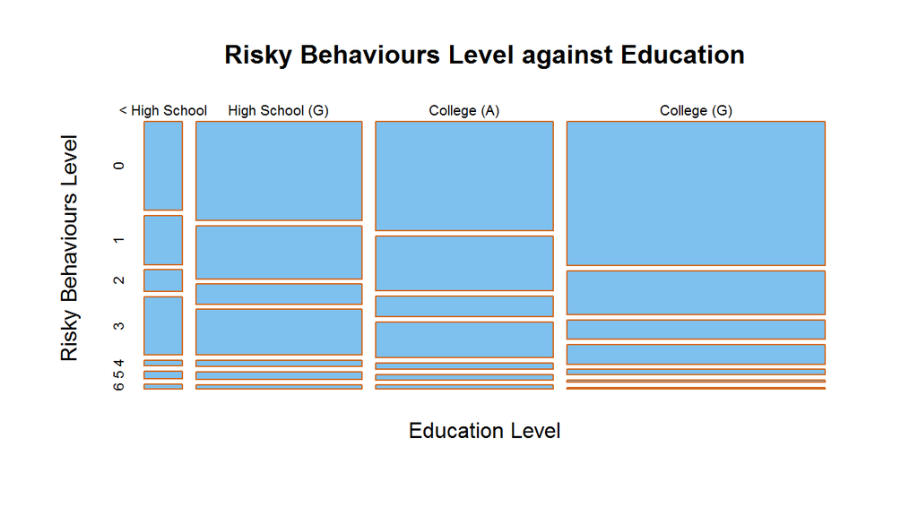

```r
educag1 <- table(brfss2013_potential_omitted$X_educag,
               brfss2013_potential_omitted$risky_behaviours_level)
mosaicplot(educag1, main = "Risky Behaviours Level against Education", xlab = "Education Level", ylab = "Risky Behaviours Level", dir = c("v", "h"),color = "skyblue2", border = "chocolate")
```

```r
educag1
```

```
##
##                       0     1     2     3     4     5     6
##   < High School    3920  2166   957  2567   229   355   206
##   High School (G) 19201 10273  3863  8808  1189  1471   831
##   College (A)     22692 11323  4235  7446  1238  1134   781
##   College (G)     43324 13115  5834  5876  1503   722   433
```

```r
chisq.test(educag1)
```

```
##
##  Pearson's Chi-squared test
##
## data:  educag1
## X-squared = 7783.8, df = 18, p-value < 2.2e-16
```

```r
rm(educag1)
```

In terms of income, visualise the expected association with contigency table and mosaic plot. In addition, conduct a chi-sqare indenpendence test, as both variables are categorical, as well as having more than two levels.

Check the conditions of such tests including the one a bit far above: we have a random sample, whose size is less than 10% of its population; both variables have exculudable division of level; and each cell has more than five observations. As all conditions are met, the null hypothesis as that the two variables are independent; while the alternative is that they are dependent.

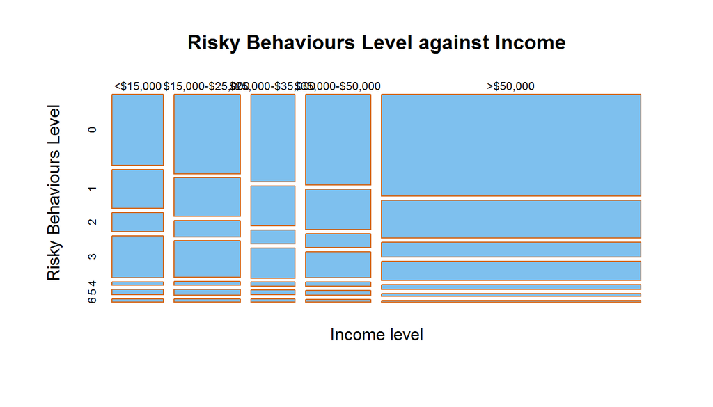

```r
incomg1 <- table(brfss2013_potential_omitted$X_incomg,
               brfss2013_potential_omitted$risky_behaviours_level)
mosaicplot(incomg1, main = "Risky Behaviours Level against Income", xlab = "Income level", ylab = "Risky Behaviours Level", dir = c("v", "h"),color = "skyblue2", border = "chocolate")
```

```r
incomg1
```

```
##
##                       0     1     2     3     4     5     6
##   <$15,000         7223  3910  1977  4226   358   515   347
##   $15,000-$25,000 10385  5025  2132  4747   509   736   390
##   $25,000-$35,000  7625  3455  1209  2631   328   383   296
##   $35,000-$50,000 11716  5203  1799  3322   557   621   358
##   >$50,000        52188 19284  7772  9771  2407  1427   860
```

```r
chisq.test(incomg1)
```

```
##
##  Pearson's Chi-squared test
##
## data:  incomg1
## X-squared = 4541.5, df = 24, p-value < 2.2e-16
```

```r
rm(incomg1, brfss2013_potential_omitted)
```

According to the test result reports above, we have a fairly high chi-square values and two p-values approximately 0. Therefore, we should reject the nulls, concluding that we are 99% confident that education and income level are omitted variables that account for the association in the previous research question somehow. Combined with the preceding graphs, **we are 99% confident that education and income level are dependent with the likelihood of detrimental risky behaviours, potentially negatively either, among the whole adult population aged from 18 to 64 residing in the US households within landline telephone coverage in the year 2013.**

### Research quesion 3:

For research question 3, we would like to investigate in the potential habits that contribute to body mass. To name a few, the length of sleep and excercise time, as well as the consumption of fruit and vegetable. We should also take one of the strongest determinants of weight, intuitively the factor of height, in case of need.

```r
brfss2013_weight_habits <- brfss2013_cell_private_residence %>%
  select(X_age65yr, wtkg3, sleptim1, exerhmm1, X_frutsum, X_vegesum, htm4)
str(brfss2013_weight_habits)
```

```
## 'data.frame':    24621 obs. of  7 variables:
##  $ X_age65yr: Factor w/ 2 levels "Age 18 to 64",..: 2 1 2 1 1 1 1 1 1 1 ...
##  $ wtkg3    : int  7257 7711 6486 9979 9979 5443 8845 7938 9299 NA ...
##  $ sleptim1 : int  8 6 4 6 6 6 6 6 5 7 ...
##  $ exerhmm1 : int  40 45 100 NA 22 130 30 300 100 NA ...
##  $ X_frutsum: num  100 100 100 286 200 74 172 3 43 NA ...
##  $ X_vegesum: num  107 100 213 117 350 200 172 139 77 NA ...
##  $ htm4     : int  165 178 157 183 183 165 168 180 165 170 ...
```

**Elimination of Observations**

According to the population of interest, we should eliminate the sampled adults aged 65 or older. We need to get rid of observations with any `"NA"` value for the listed variables, additionally.

```r
brfss2013_weight_habits <- brfss2013_weight_habits %>%
  filter(X_age65yr=="Age 18 to 64" &
         wtkg3 != "NA" &
         sleptim1 != "NA" &
         exerhmm1 != "NA" &
         X_frutsum != "NA" &
         X_vegesum != "NA" &
         htm4 != "NA")
```

**Additional Adjustments to Variables**

As instructed by the BRFSS codebook, there are two implied decimal places for the variable `wtkg3`, `_frutsum`, and `_vegesum`; we need to adjust the unit of the variable `exerhmm1`, which implies the minutes (or hours when the variable takes the value `"1"`) of execercise per day to hours, in order to keep it identical with that of `sleptim1`, in favor of interpretation; and we need to exclude those reported consuming fruit over 16 per day, as well as those reported consuming vegetables over 23 per day. Moreover, as there is two implied decimal places for the variablewe `htm4`, there is no need to transfer its unit from meters to centimeters mathmatically. The unit itself can be simply regarded as being in centimeters.

```r
brfss2013_weight_habits$wtkg3 = brfss2013_weight_habits$wtkg3/100
brfss2013_weight_habits$X_frutsum = brfss2013_weight_habits$X_frutsum/100
brfss2013_weight_habits$X_vegesum = brfss2013_weight_habits$X_vegesum/100
brfss2013_weight_habits <- brfss2013_weight_habits %>%
  filter(X_frutsum <= 16 & X_vegesum <= 23)
brfss2013_weight_habits$exerhmm1[brfss2013_weight_habits$exerhmm1 < 2] <- 60
brfss2013_weight_habits$exerhmm1 = brfss2013_weight_habits$exerhmm1/60
```

As all the components are ready, we can use the function `ggpair` to get a rough view of the relations among the listed numerical independent variables.

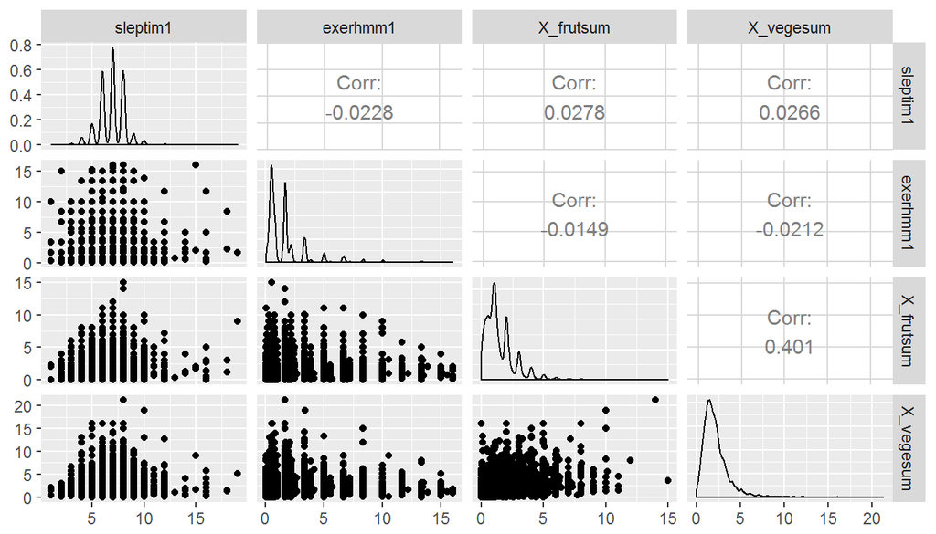

```r
ggpairs(brfss2013_weight_habits, columns=3:6)
```

The independent variables are not strongly colinear with each other, so it’s acceptable to take them into a multivariate linear model as predictors. Then we can fit the model in the following chunk.

```r
m_weight <- lm(wtkg3~sleptim1+ exerhmm1+ X_frutsum+ X_vegesum, data=brfss2013_weight_habits)
summary(m_weight)
```

```
##
## Call:
## lm(formula = wtkg3 ~ sleptim1 + exerhmm1 + X_frutsum + X_vegesum,
##     data = brfss2013_weight_habits)
##
## Residuals:
##     Min      1Q  Median      3Q     Max
## -52.315 -14.482  -2.095  11.028 145.317
##
## Coefficients:
##             Estimate Std. Error t value Pr(>|t|)
## (Intercept)  91.6314     0.9247  99.098  < 2e-16 ***
## sleptim1     -1.2089     0.1254  -9.638  < 2e-16 ***
## exerhmm1      0.4609     0.0845   5.454 5.00e-08 ***
## X_frutsum    -0.8939     0.1442  -6.197 5.91e-10 ***
## X_vegesum    -0.5969     0.1229  -4.856 1.21e-06 ***
## ---
## Signif. codes:  0 '***' 0.001 '**' 0.01 '*' 0.05 '.' 0.1 ' ' 1
##
## Residual standard error: 19.79 on 15190 degrees of freedom
## Multiple R-squared:  0.01533,    Adjusted R-squared:  0.01507
## F-statistic: 59.12 on 4 and 15190 DF,  p-value: < 2.2e-16
```

Although all the coefficients are significant even with a significance level of 1%, it’s worrisome that the adjusted R-squared is way too low. Consider taking the direct determinant, height into the linear model. As usual, use `ggpairs` to check the colinearity among independent variables before modeling.

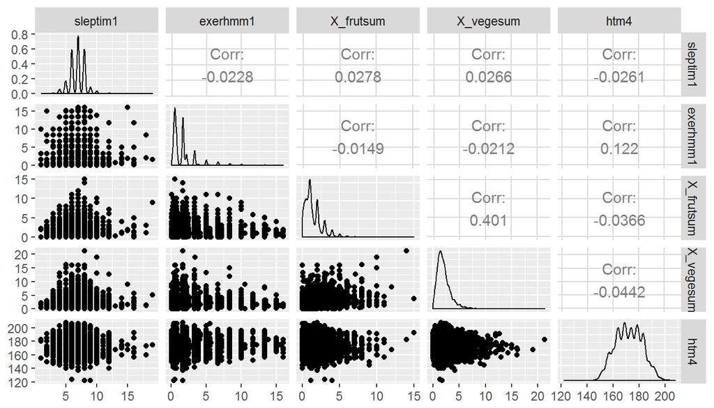

```r
ggpairs(brfss2013_weight_habits, columns=3:7)
```

No strong colinearity as expected, and we can fit the linear model for weight with height in the following chunk.

```r
m_weight_h <- lm(wtkg3~htm4+sleptim1+ exerhmm1+ X_frutsum+ X_vegesum, data=brfss2013_weight_habits)
summary(m_weight_h)
```

```
##
## Call:
## lm(formula = wtkg3 ~ htm4 + sleptim1 + exerhmm1 + X_frutsum +
##     X_vegesum, data = brfss2013_weight_habits)
##
## Residuals:
##     Min      1Q  Median      3Q     Max
## -52.431 -11.645  -2.795   8.338 131.824
##
## Coefficients:
##              Estimate Std. Error t value Pr(>|t|)
## (Intercept) -83.22762    2.43504 -34.179  < 2e-16 ***
## htm4          1.01022    0.01331  75.886  < 2e-16 ***
## sleptim1     -1.02994    0.10683  -9.641  < 2e-16 ***
## exerhmm1     -0.20407    0.07249  -2.815 0.004881 **
## X_frutsum    -0.71219    0.12286  -5.797  6.9e-09 ***
## X_vegesum    -0.35718    0.10471  -3.411 0.000649 ***
## ---
## Signif. codes:  0 '***' 0.001 '**' 0.01 '*' 0.05 '.' 0.1 ' ' 1
##
## Residual standard error: 16.86 on 15189 degrees of freedom
## Multiple R-squared:  0.286,  Adjusted R-squared:  0.2858
## F-statistic:  1217 on 5 and 15189 DF,  p-value: < 2.2e-16
```

All coefficients stay significant with a significance level of 5% and the adjusted R-square raised drastically to a satisfactory level, 0.29. Use the present model as our final version and check the conditions of it.

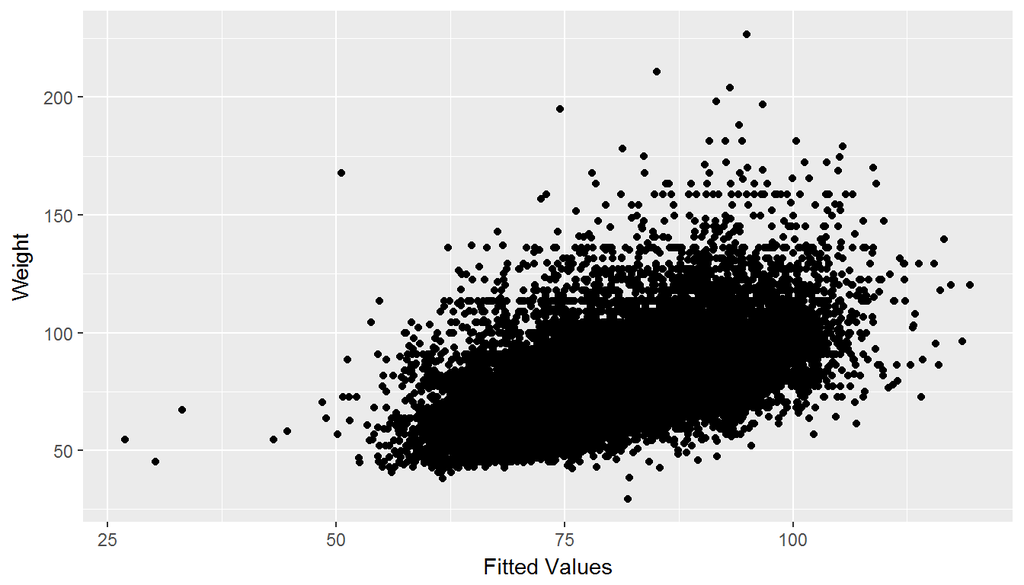

```r
ggplot(data=m_weight_h, aes(x=.fitted, y=wtkg3))+geom_jitter()+xlab("Fitted Values")+ylab("Weight")
```

With diagonostic A, as shown by the scatter plot of weights against fitted values, the linearity condition is roughly satisfied.

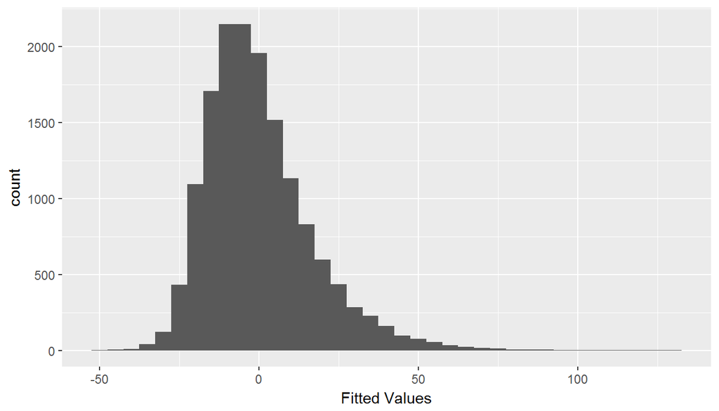

```r
ggplot(data=m_weight_h, aes(x=.resid)) + geom_histogram(binwidth=5) + xlab("Fitted Values")
```

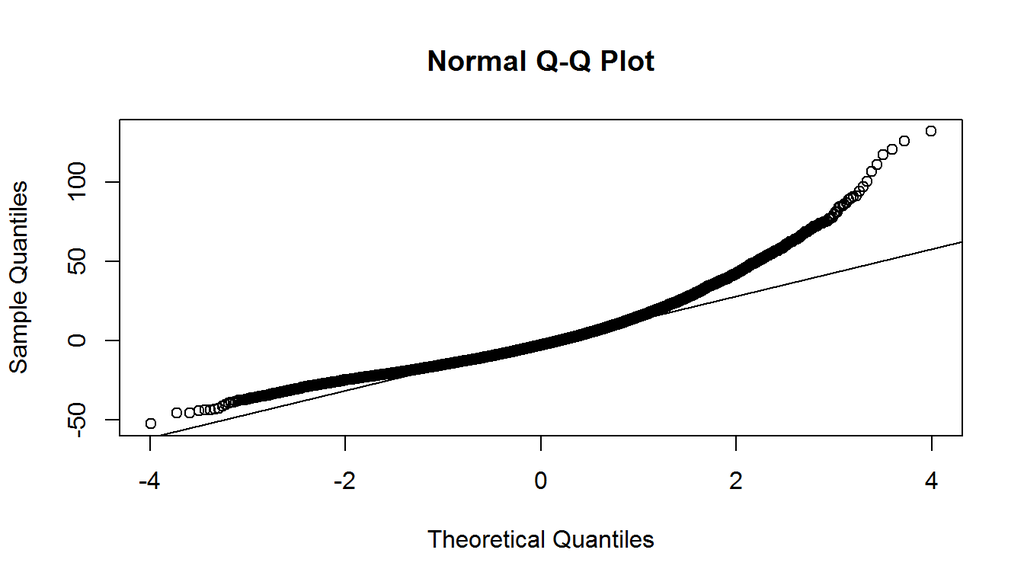

```r
qqnorm(m_weight_h$residuals)
qqline(m_weight_h$residuals)
```

With diagnostic B, the distribution of residuals shows a right-skewed patern. However, the sample is large enough to offset the skew, and we can assume that the residuals follow a nearly normal distribution.

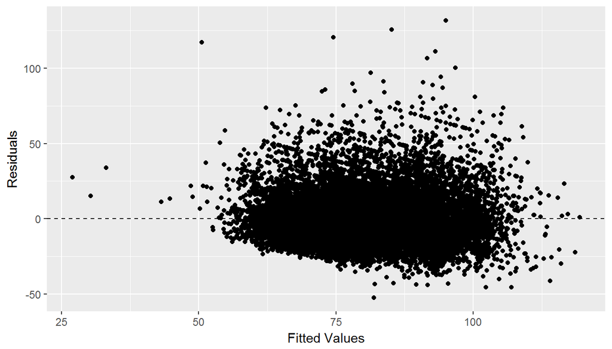

```r
ggplot(data=m_weight_h, aes(x=.fitted, y=.resid))+geom_jitter()+geom_hline(yintercept=0, linetype="dashed")+xlab("Fitted Values")+ylab("Residuals")
```

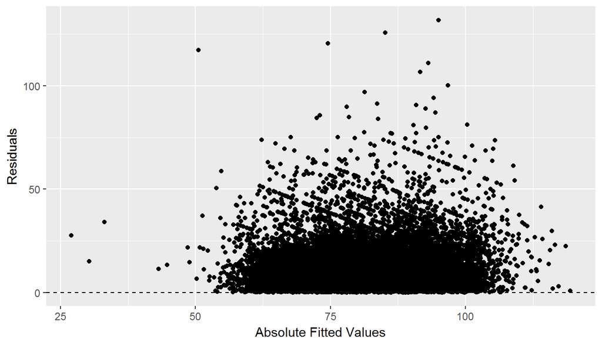

```r
ggplot(data=m_weight_h, aes(x=.fitted, y=abs(.resid)))+geom_jitter()+geom_hline(yintercept=0, linetype="dashed")+xlab("Absolute Fitted Values")+ylab("Residuals")
```

With diagnostic C, the scatter plot of residuals against fitted values show a curved pattern, and it’s more obvious in the second plot of absolute values of residuals against fitted values, the dispersion changes along with the fitted value and reach its achme at approximately the middle of the distribution. But the trend is not significant enough to refuse our model, the scatters are roughly radomly distributed. We can assume that the variability of residuals to be relatively constant.

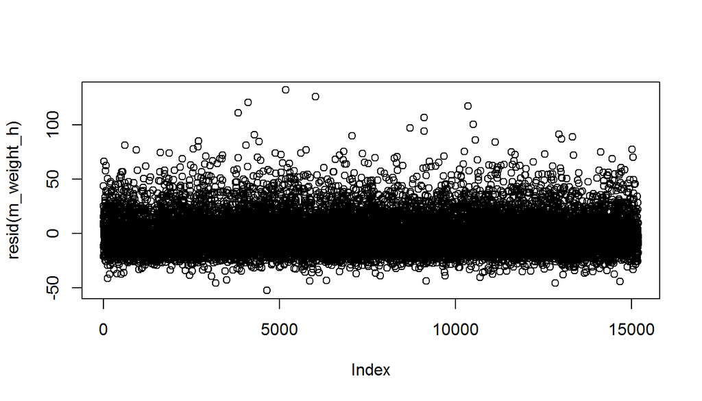

```r
plot(resid(m_weight_h))
```

```r
rm(m_weight, m_weight_h, brfss2013_weight_habits)
```

With diagnostic D, the residuals show no trend along time (or order), the residuals are independent.